## Blood pressure

Mixed-effects model estimates for systolic blood pressure (mmHg)

Unadjusted

- Period effect
- Baselines

Predictors

Estimates

CI

p

Estimates

CI

p

Estimates

CI

p

Intercept

137.89

133.87 – 141.91

**<0.001**

138.52

134.33 – 142.72

**<0.001**

136.78

133.59 – 139.97

**<0.001**

Treatment

0.04

-2.31 – 2.39

0.974

0.03

-2.32 – 2.37

0.983

-0.40

-3.18 – 2.38

0.781

Sex

-2.37

-8.24 – 3.51

0.432

-2.38

-8.25 – 3.50

0.430

1.16

-2.66 – 4.99

0.553

Period

-1.22

-3.57 – 1.12

0.310

-0.18

-2.97 – 2.61

0.900

SBP Baseline

0.70

0.56 – 0.84

**<0.001**

Random Effects

σ<sup>2</sup>

56.73

56.75

79.05

τ<sub>00</sub>

147.23 <sub>subj_id</sub>

147.06 <sub>subj_id</sub>

31.61 <sub>subj_id</sub>

ICC

0.72

0.72

0.29

N

80 <sub>subj_id</sub>

80 <sub>subj_id</sub>

80 <sub>subj_id</sub>

Observations

159

159

158

Marginal R<sup>2</sup> / Conditional R<sup>2</sup>

0.007 / 0.724

0.009 / 0.724

0.407 / 0.576

Mixed-effects model estimates for diastolic blood pressure (mmHg)

Unadjusted

- Period effect
- Baselines

Predictors

Estimates

CI

p

Estimates

CI

p

Estimates

CI

p

Intercept

89.74

87.12 – 92.37

**<0.001**

90.55

87.80 – 93.30

**<0.001**

89.65

87.44 – 91.87

**<0.001**

Treatment

-0.40

-2.03 – 1.23

0.632

-0.42

-2.01 – 1.18

0.611

-0.43

-2.21 – 1.35

0.638

Sex

-1.37

-5.18 – 2.45

0.485

-1.38

-5.20 – 2.43

0.480

0.17

-2.60 – 2.93

0.906

Period

-1.57

-3.16 – 0.03

0.058

-1.22

-3.00 – 0.57

0.186

DBP Baseline

0.58

0.43 – 0.72

**<0.001**

Random Effects

σ<sup>2</sup>

27.22

26.29

32.56

τ<sub>00</sub>

60.28 <sub>subj_id</sub>

60.82 <sub>subj_id</sub>

21.59 <sub>subj_id</sub>

ICC

0.69

0.70

0.40

N

80 <sub>subj_id</sub>

80 <sub>subj_id</sub>

80 <sub>subj_id</sub>

Observations

159

159

158

Marginal R<sup>2</sup> / Conditional R<sup>2</sup>

0.006 / 0.691

0.013 / 0.702

0.315 / 0.588

Mixed-effects model estimates for central systolic blood pressure (mmHg)

Unadjusted

- Period effect
- Baselines

Predictors

Estimates

CI

p

Estimates

CI

p

Estimates

CI

p

Intercept

138.66

134.57 – 142.76

**<0.001**

138.66

134.39 – 142.93

**<0.001**

140.01

136.81 – 143.21

**<0.001**

Treatment

1.43

-0.93 – 3.79

0.240

1.43

-0.95 – 3.80

0.243

0.47

-2.43 – 3.36

0.753

Sex

1.71

-4.30 – 7.73

0.578

1.72

-4.30 – 7.74

0.578

0.59

-3.18 – 4.35

0.762

Period

0.01

-2.37 – 2.38

0.995

-0.66

-3.55 – 2.23

0.657

C SBP Baseline

0.67

0.54 – 0.81

**<0.001**

Random Effects

σ<sup>2</sup>

56.73

57.48

85.44

τ<sub>00</sub>

155.38 <sub>subj_id</sub>

155.01 <sub>subj_id</sub>

28.49 <sub>subj_id</sub>

ICC

0.73

0.73

0.25

N

80 <sub>subj_id</sub>

80 <sub>subj_id</sub>

80 <sub>subj_id</sub>

Observations

158

158

158

Marginal R<sup>2</sup> / Conditional R<sup>2</sup>

0.006 / 0.734

0.006 / 0.731

0.418 / 0.564

Mixed-effects model estimates for central diastolic blood pressure (mmHg)

Unadjusted

- Period effect
- Baselines

Predictors

Estimates

CI

p

Estimates

CI

p

Estimates

CI

p

Intercept

79.45

77.70 – 81.20

**<0.001**

80.05

78.17 – 81.93

**<0.001**

79.18

77.52 – 80.83

**<0.001**

Treatment

-0.12

-1.51 – 1.28

0.871

-0.12

-1.49 – 1.26

0.870

-0.12

-1.62 – 1.38

0.877

Sex

-5.00

-7.47 – -2.53

**<0.001**

-5.02

-7.50 – -2.55

**<0.001**

-3.11

-5.10 – -1.11

**0.003**

Period

-1.18

-2.56 – 0.20

0.097

-1.03

-2.54 – 0.47

0.182

C DBP Baseline

0.38

0.27 – 0.50

**<0.001**

Random Effects

σ<sup>2</sup>

19.82

19.36

23.12

τ<sub>00</sub>

21.02 <sub>subj_id</sub>

21.25 <sub>subj_id</sub>

6.79 <sub>subj_id</sub>

ICC

0.51

0.52

0.23

N

80 <sub>subj_id</sub>

80 <sub>subj_id</sub>

80 <sub>subj_id</sub>

Observations

158

158

158

Marginal R<sup>2</sup> / Conditional R<sup>2</sup>

0.131 / 0.578

0.138 / 0.589

0.333 / 0.485

## Other outcomes

Mixed-effects model estimates for log(OXLDL)

Unadjusted

- Period effect
- Baselines

Predictors

Estimates

CI

p

Estimates

CI

p

Estimates

CI

p

Intercept

4.00

3.89 – 4.10

**<0.001**

3.97

3.85 – 4.08

**<0.001**

3.99

3.88 – 4.09

**<0.001**

Treatment

0.07

-0.02 – 0.15

0.135

0.07

-0.02 – 0.15

0.130

0.07

-0.02 – 0.15

0.144

Sex

-0.05

-0.20 – 0.10

0.500

-0.05

-0.20 – 0.10

0.505

-0.01

-0.13 – 0.12

0.886

Period

0.06

-0.03 – 0.14

0.193

-0.01

-0.10 – 0.08

0.749

OXLDL Baseline

0.48

0.31 – 0.65

**<0.001**

Random Effects

σ<sup>2</sup>

0.07

0.07

0.08

τ<sub>00</sub>

0.08 <sub>subj_id</sub>

0.08 <sub>subj_id</sub>

0.04 <sub>subj_id</sub>

ICC

0.51

0.52

0.34

N

80 <sub>subj_id</sub>

80 <sub>subj_id</sub>

80 <sub>subj_id</sub>

Observations

157

157

157

Marginal R<sup>2</sup> / Conditional R<sup>2</sup>

0.012 / 0.518

0.017 / 0.524

0.186 / 0.462

Mixed-effects model estimates for arterial stiffness

Unadjusted

- Period effect
- Baselines

Predictors

Estimates

CI

p

Estimates

CI

p

Estimates

CI

p

Intercept

9.07

8.72 – 9.41

**<0.001**

9.11

8.73 – 9.48

**<0.001**

9.09

8.75 – 9.43

**<0.001**

Treatment

0.05

-0.24 – 0.34

0.713

0.05

-0.24 – 0.35

0.713

0.02

-0.30 – 0.34

0.901

Sex

-0.27

-0.76 – 0.21

0.273

-0.27

-0.76 – 0.21

0.271

-0.19

-0.59 – 0.20

0.344

Period

-0.08

-0.37 – 0.21

0.587

-0.10

-0.42 – 0.23

0.561

Stiffness Baseline

0.33

0.21 – 0.46

**<0.001**

Random Effects

σ<sup>2</sup>

0.86

0.87

1.05

τ<sub>00</sub>

0.75 <sub>subj_id</sub>

0.74 <sub>subj_id</sub>

0.24 <sub>subj_id</sub>

ICC

0.47

0.46

0.19

N

79 <sub>subj_id</sub>

79 <sub>subj_id</sub>

79 <sub>subj_id</sub>

Observations

157

157

157

Marginal R<sup>2</sup> / Conditional R<sup>2</sup>

0.012 / 0.472

0.013 / 0.469

0.172 / 0.327

Mixed-effects model estimates for fasting glucose

Unadjusted

- Period effect
- Baselines

Predictors

Estimates

CI

p

Estimates

CI

p

Estimates

CI

p

Intercept

5.36

5.19 – 5.53

**<0.001**

5.36

5.18 – 5.54

**<0.001**

5.34

5.19 – 5.49

**<0.001**

Treatment

0.09

-0.04 – 0.21

0.172

0.09

-0.04 – 0.22

0.174

0.10

-0.05 – 0.25

0.203

Sex

-0.29

-0.52 – -0.05

**0.021**

-0.29

-0.52 – -0.05

**0.021**

-0.13

-0.29 – 0.04

0.141

Period

-0.01

-0.13 – 0.12

0.906

-0.10

-0.26 – 0.05

0.194

Glucose Baseline

0.55

0.42 – 0.68

**<0.001**

Random Effects

σ<sup>2</sup>

0.16

0.16

0.24

τ<sub>00</sub>

0.20 <sub>subj_id</sub>

0.20 <sub>subj_id</sub>

0.01 <sub>subj_id</sub>

ICC

0.57

0.56

0.05

N

79 <sub>subj_id</sub>

79 <sub>subj_id</sub>

79 <sub>subj_id</sub>

Observations

155

155

154

Marginal R<sup>2</sup> / Conditional R<sup>2</sup>

0.058 / 0.590

0.058 / 0.586

0.350 / 0.382

Mixed-effects model estimates for LDL

Unadjusted

- Period effect
- Baselines

Predictors

Estimates

CI

p

Estimates

CI

p

Estimates

CI

p

Intercept

3.00

2.75 – 3.25

**<0.001**

3.01

2.74 – 3.28

**<0.001**

3.00

2.80 – 3.19

**<0.001**

Treatment

0.09

-0.09 – 0.27

0.328

0.09

-0.09 – 0.27

0.330

0.02

-0.18 – 0.21

0.847

Sex

0.06

-0.30 – 0.42

0.740

0.06

-0.30 – 0.42

0.740

0.06

-0.14 – 0.26

0.566

Period

-0.02

-0.20 – 0.16

0.843

0.07

-0.13 – 0.26

0.514

LDL Baseline

0.75

0.63 – 0.87

**<0.001**

Random Effects

σ<sup>2</sup>

0.33

0.33

0.38

τ<sub>00</sub>

0.47 <sub>subj_id</sub>

0.47 <sub>subj_id</sub>

0.02 <sub>subj_id</sub>

ICC

0.59

0.58

0.04

N

79 <sub>subj_id</sub>

79 <sub>subj_id</sub>

79 <sub>subj_id</sub>

Observations

155

155

153

Marginal R<sup>2</sup> / Conditional R<sup>2</sup>

0.004 / 0.589

0.004 / 0.585

0.513 / 0.533

Mixed-effects model estimates for log(HDL)

Unadjusted

- Period effect
- Baselines

Predictors

Estimates

CI

p

Estimates

CI

p

Estimates

CI

p

Intercept

0.14

0.05 – 0.22

**0.002**

0.15

0.05 – 0.24

**0.002**

0.19

0.11 – 0.27

**<0.001**

Treatment

-0.01

-0.07 – 0.06

0.884

-0.01

-0.07 – 0.06

0.886

0.05

-0.03 – 0.14

0.192

Sex

0.41

0.29 – 0.52

**<0.001**

0.40

0.29 – 0.52

**<0.001**

0.24

0.14 – 0.33

**<0.001**

Period

-0.02

-0.09 – 0.05

0.607

-0.02

-0.10 – 0.06

0.652

HDL Baseline

0.49

0.36 – 0.61

**<0.001**

Random Effects

σ<sup>2</sup>

0.05

0.05

0.06

τ<sub>00</sub>

0.05 <sub>subj_id</sub>

0.05 <sub>subj_id</sub>

0.00 <sub>subj_id</sub>

ICC

0.50

0.49

0.06

N

79 <sub>subj_id</sub>

79 <sub>subj_id</sub>

79 <sub>subj_id</sub>

Observations

155

155

153

Marginal R<sup>2</sup> / Conditional R<sup>2</sup>

0.301 / 0.650

0.301 / 0.647

0.496 / 0.526

Mixed-effects model estimates for log(total cholesterol)

Unadjusted

- Period effect
- Baselines

Predictors

Estimates

CI

p

Estimates

CI

p

Estimates

CI

p

Intercept

1.52

1.46 – 1.58

**<0.001**

1.52

1.46 – 1.58

**<0.001**

1.53

1.48 – 1.57

**<0.001**

Treatment

0.01

-0.03 – 0.06

0.534

0.01

-0.03 – 0.06

0.536

0.03

-0.02 – 0.08

0.276

Sex

0.13

0.05 – 0.21

**0.003**

0.13

0.05 – 0.21

**0.003**

0.07

0.02 – 0.12

**0.005**

Period

0.00

-0.04 – 0.05

0.861

0.02

-0.02 – 0.07

0.326

TCHOL Baseline

0.67

0.55 – 0.78

**<0.001**

Random Effects

σ<sup>2</sup>

0.02

0.02

0.02

τ<sub>00</sub>

0.02 <sub>subj_id</sub>

0.02 <sub>subj_id</sub>

0.00 <sub>subj_id</sub>

ICC

0.58

0.57

N

79 <sub>subj_id</sub>

79 <sub>subj_id</sub>

79 <sub>subj_id</sub>

Observations

154

154

153

Marginal R<sup>2</sup> / Conditional R<sup>2</sup>

0.087 / 0.615

0.087 / 0.611

Mixed-effects model estimates for log(TAG)

Unadjusted

- Period effect
- Baselines

Predictors

Estimates

CI

p

Estimates

CI

p

Estimates

CI

p

Intercept

-0.14

-0.32 – 0.04

0.134

-0.15

-0.33 – 0.04

0.132

-0.25

-0.38 – -0.12

**<0.001**

Treatment

-0.03

-0.14 – 0.08

0.584

-0.03

-0.14 – 0.08

0.581

-0.01

-0.13 – 0.11

0.890

Sex

-0.16

-0.42 – 0.10

0.235

-0.16

-0.42 – 0.10

0.235

0.03

-0.11 – 0.17

0.707

Period

0.01

-0.10 – 0.13

0.804

0.03

-0.09 – 0.16

0.588

TAG Baseline

0.74

0.63 – 0.85

**<0.001**

Random Effects

σ<sup>2</sup>

0.12

0.12

0.15

τ<sub>00</sub>

0.27 <sub>subj_id</sub>

0.27 <sub>subj_id</sub>

0.02 <sub>subj_id</sub>

ICC

0.69

0.69

0.12

N

78 <sub>subj_id</sub>

78 <sub>subj_id</sub>

78 <sub>subj_id</sub>

Observations

152

152

151

Marginal R<sup>2</sup> / Conditional R<sup>2</sup>

0.016 / 0.694

0.016 / 0.691

0.563 / 0.615

Mixed-effects model estimates for PWA augment

Unadjusted

- Period effect
- Baselines

Predictors

Estimates

CI

p

Estimates

CI

p

Estimates

CI

p

Intercept

24.74

23.02 – 26.46

**<0.001**

24.63

22.77 – 26.50

**<0.001**

25.37

23.75 – 27.00

**<0.001**

Treatment

0.63

-0.79 – 2.04

0.388

0.63

-0.79 – 2.04

0.391

-0.11

-1.79 – 1.58

0.903

Sex

4.41

1.99 – 6.82

**0.001**

4.41

1.99 – 6.83

**0.001**

2.74

0.99 – 4.48

**0.003**

Period

0.21

-1.21 – 1.63

0.775

0.80

-0.88 – 2.48

0.354

PWA AUGMENT Baseline

0.50

0.37 – 0.62

**<0.001**

Random Effects

σ<sup>2</sup>

20.35

20.59

28.80

τ<sub>00</sub>

19.36 <sub>subj_id</sub>

19.26 <sub>subj_id</sub>

0.00 <sub>subj_id</sub>

ICC

0.49

0.48

N

80 <sub>subj_id</sub>

80 <sub>subj_id</sub>

80 <sub>subj_id</sub>

Observations

158

158

158

Marginal R<sup>2</sup> / Conditional R<sup>2</sup>

0.109 / 0.544

0.109 / 0.540

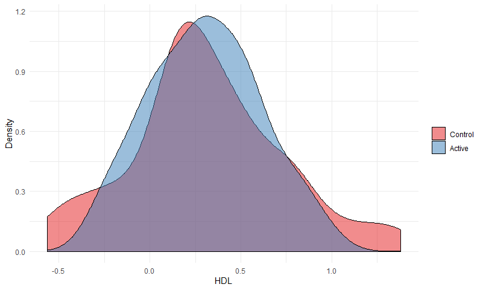

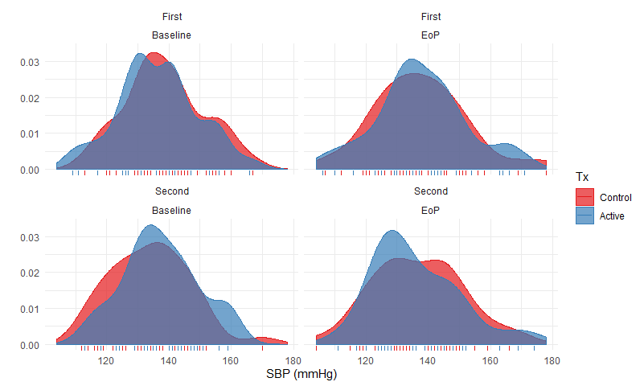

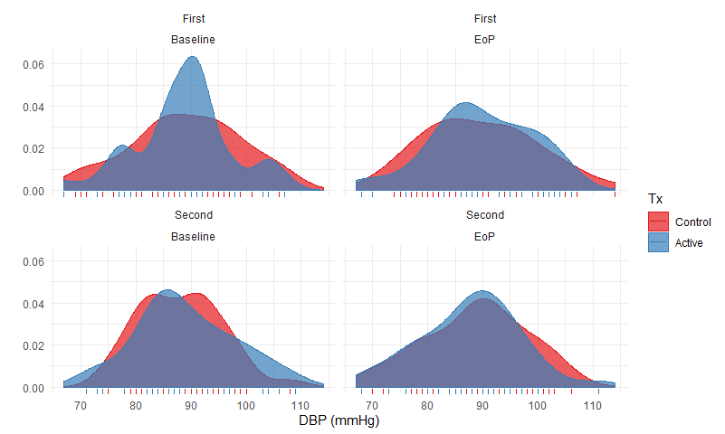

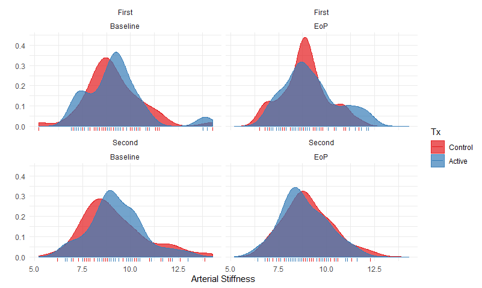

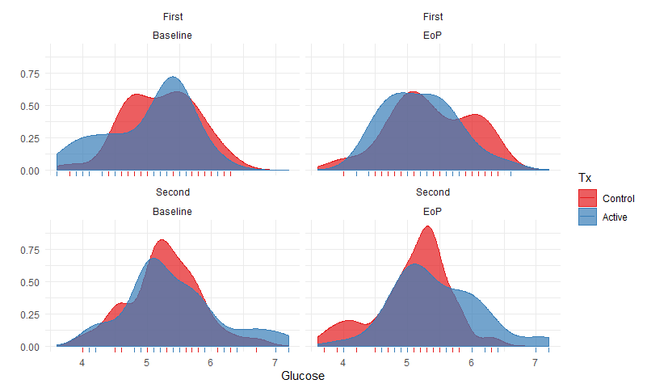

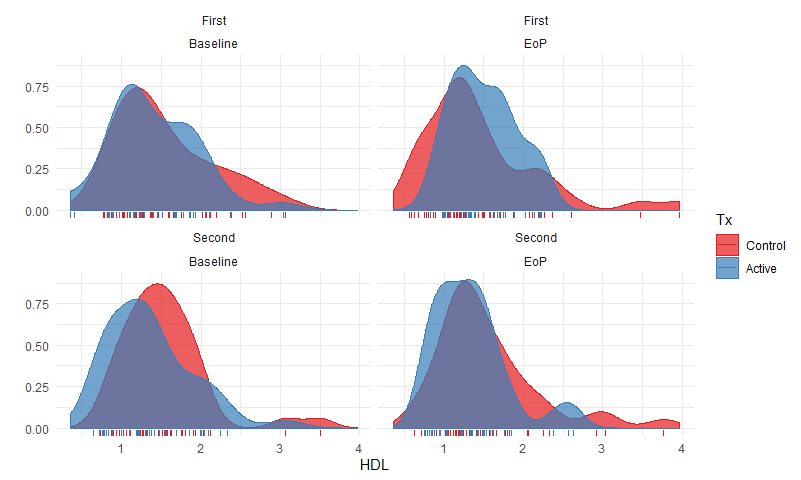

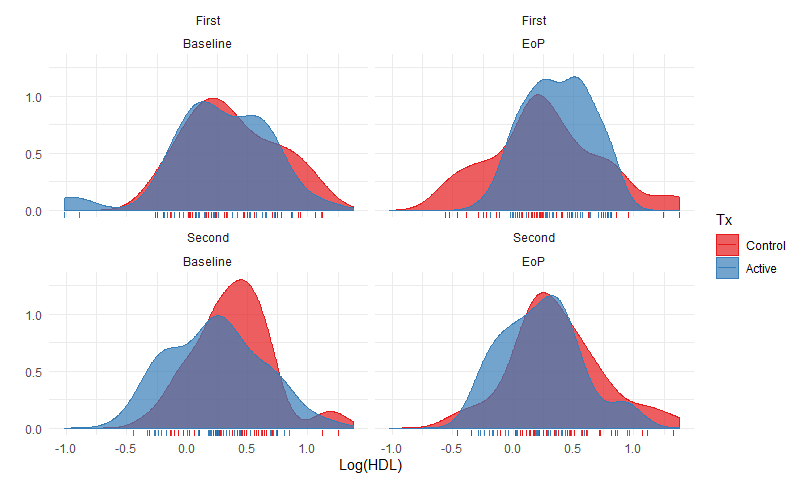

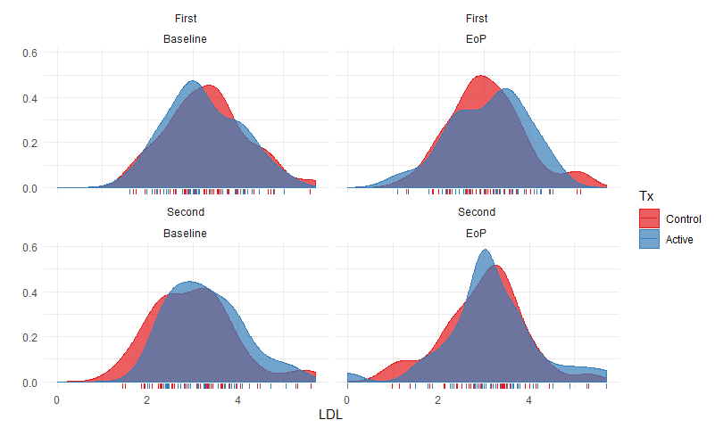

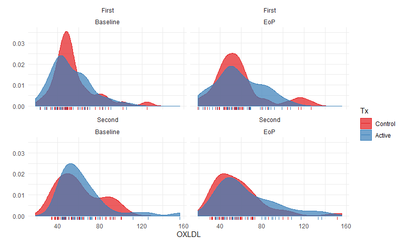

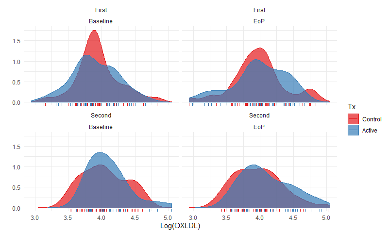

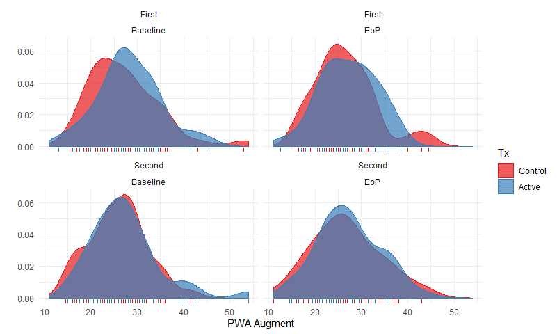

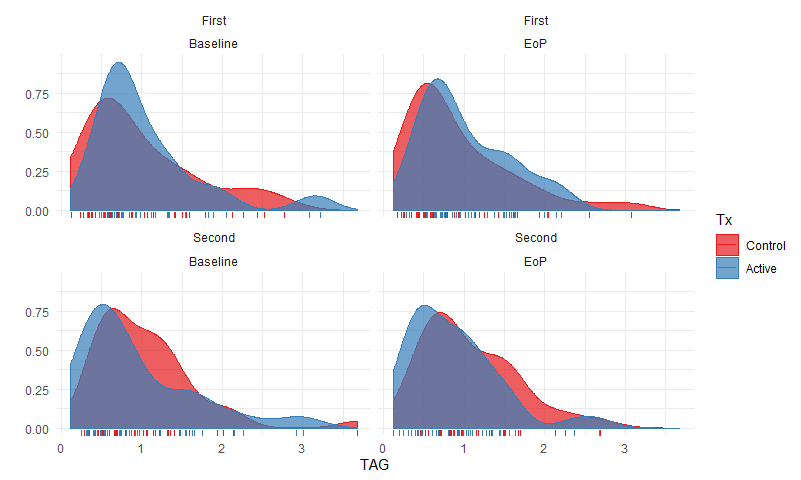

[3 more figures not shown]